# mixed-models-workshop

2023-03-10

## What are mixed models and why should we use them?

**Mixed effects models** are an extension of linear models that include a combination of fixed and random effects (Bolker et al. 2009; Harrison et al. 2018).

Mixed effects models and the introduction of random effects have a number of key (non-mutually exclusive) benefits (adapted from Harrison et al. 2018):

1. **Complex datasets with built in non-independence:** Biological datasets are often highly structured, containing clusters of **non-independent observational units** that are hierarchical in nature, and mixed models allow us to explicitly model the non-independence in such data.
2. **Improved inference:** Explicit modelling of the random effects structure will improve inference about fixed effects, depending on which level of the system’s hierarchy is being manipulated.
3. **Grouping variables:** Random effects typically represent some **grouping variable** and allow the estimation of variance in the response variable within and among these groups, which reduces the probability of false positives (Type I error rates) and false negatives (Type II error rates).

## Mixed model resources:

For more details, code, and more information on using mixed effects models see the following online resources:

1. [Our coding club](https://ourcodingclub.github.io/tutorials/mixed-models/%3E)
2. [Is it fixed or random?](https://dynamicecology.wordpress.com/2015/11/04/is-it-a-fixed-or-random-effect/)
3. [Why are our models so complex?](https://dynamicecology.wordpress.com/2014/12/02/why-are-your-statistical-models-more-complex-these-days/)

And the following published articles and books:

1. Harrison et al. 2018 A brief introduction to mixed effects modelling and multi-model inference in ecology
2. [Bolker et al. 2009 Generalized linear mixed models: a practical guide for ecology and evolution](https://www.sciencedirect.com/science/article/pii/S0169534709000196?via%3Dihub)
3. [Zuur et al. 2009 Mixed Effects Models and Extensions in Ecology with R](https://link.springer.com/book/10.1007/978-0-387-87458-6)

## load key libraries

```r
library(lme4)
library(nlme)
library(ggplot2)
library(tidyverse)
```

## When should we use mixed models:

Mixed models are most appropriate when:

1. Data have inherent **non-independence** through nested variables
2. One or more variable are **grouped** and (as the user) we want to account for variance within and among groups, but not we are not interested in the statistical effect of that grouped variable on our response variable.

## Example data

We will use the [dragon](http://gkhajduk.d.pr/9GPn/3nbbPoK6) data, which includes data on body length and test score for dragons from 8 mountain ranges. Within each mountain range there are three sites (a, b, and c).

We will follow prior examples using these data from [Elise Gallois](https://ourcodingclub.github.io/tutorials/mixed-models/).

## Explore the data

```r
## load dragon data
load("dragons.RData")

## convert to tibble and check out the columns
dragons <- as_tibble(dragons)

## remove X column and
dragons <-
    dragons %>%
    select(-X)

## view head of dataset
head(dragons)
```

```
## # A tibble: 6 × 4
##   testScore bodyLength mountainRange site
##       <dbl>      <dbl> <fct>         <fct>
## 1     16.1        166. Bavarian      a
## 2     33.9        168. Bavarian      a
## 3      6.04       166. Bavarian      a
## 4     18.8        168. Bavarian      a
## 5     33.9        170. Bavarian      a
## 6     47.0        169. Bavarian      a
```

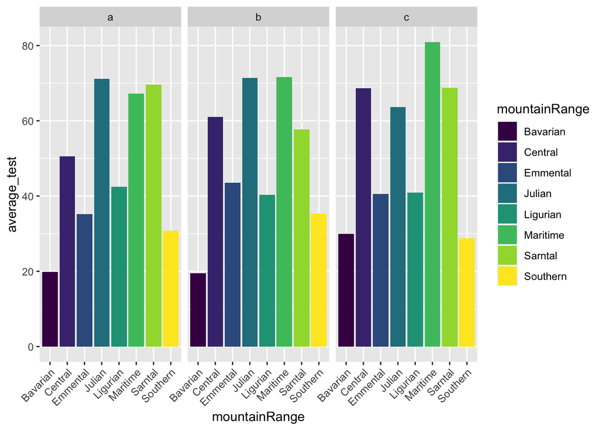

```r
## plot differences in mean test scores across mountain ranges and sites
dragons %>%
  select(mountainRange, site, testScore) %>%
  filter(!is.na(testScore)) %>%
  group_by(mountainRange, site) %>%
  summarise(average_test = mean(testScore)) %>%
  ggplot(aes(x = mountainRange,
             y = average_test,
             fill = mountainRange)) +
  geom_col() +
  scale_fill_viridis_d() +
  theme(axis.text.x = element_text(hjust = 1, angle = 45)) +
  facet_wrap(~ site)
```

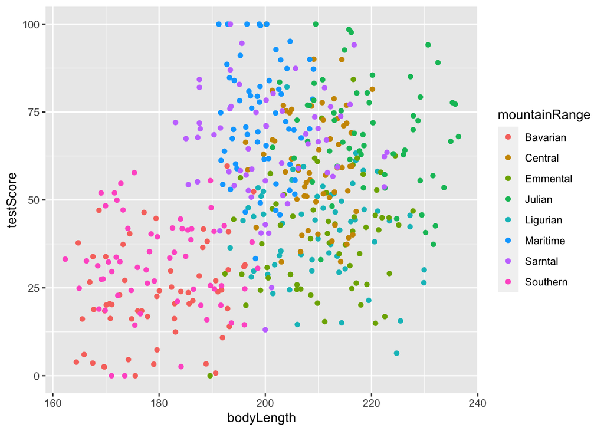

```r
## plot relationship between test score and body length by mountain range
dragons %>%
  ggplot(aes(x = bodyLength,
             y = testScore,
             color = mountainRange)) +
  geom_point()
```

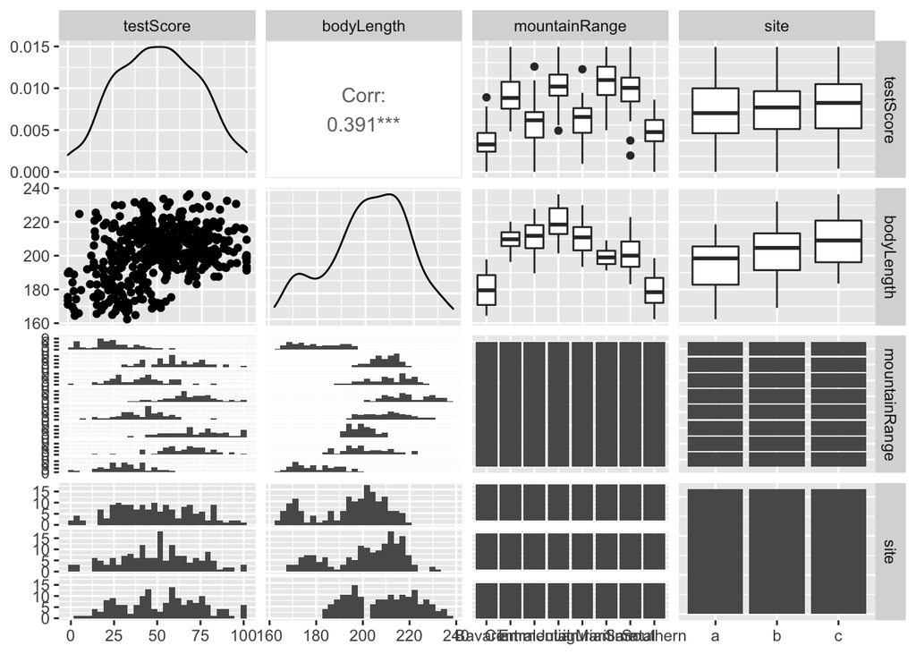

```r
## check relationships between all pairwise combinations of variables
dragons %>% GGally::ggpairs()
```

## Considering our exploratory analysis

It looks like test score varies between mountain ranges and it also looks like the relationship between test score and body length varies between mountain ranges. If we are interested in the biological effect of mountain range on test score (maybe mountain range is a proxy for food availability), we would consider using linear models. If we aren’t really interested in the biological effect of mountain range on the test score or on the relationship between test score and body length, we would consider using linear mixed models.

## Model test score against body length and mountain range using linear model

```r
model1 <- lm(testScore ~ bodyLength + mountainRange, data = dragons)
summary(model1)
```

```
##
## Call:
## lm(formula = testScore ~ bodyLength + mountainRange, data = dragons)
##
## Residuals:
##     Min      1Q  Median      3Q     Max
## -52.263  -9.926   0.361   9.994  44.488
##
## Coefficients:
##                       Estimate Std. Error t value Pr(>|t|)
## (Intercept)           20.83051   14.47218   1.439  0.15072
## bodyLength             0.01267    0.07974   0.159  0.87379
## mountainRangeCentral  36.58277    3.59929  10.164  < 2e-16 ***
## mountainRangeEmmental 16.20923    3.69665   4.385 1.43e-05 ***
## mountainRangeJulian   45.11469    4.19012  10.767  < 2e-16 ***
## mountainRangeLigurian 17.74779    3.67363   4.831 1.84e-06 ***
## mountainRangeMaritime 49.88133    3.13924  15.890  < 2e-16 ***
## mountainRangeSarntal  41.97841    3.19717  13.130  < 2e-16 ***
## mountainRangeSouthern  8.51961    2.73128   3.119  0.00192 **
## ---
## Signif. codes:  0 '***' 0.001 '**' 0.01 '*' 0.05 '.' 0.1 ' ' 1
##
## Residual standard error: 14.96 on 471 degrees of freedom
## Multiple R-squared:  0.5843, Adjusted R-squared:  0.5773
## F-statistic: 82.76 on 8 and 471 DF,  p-value: < 2.2e-16
```

## Interpretation of linear model

Our interpretation of this model is that body length does not affect test score, though there are differences in test score across mountain ranges. If we are not interested in testing for differences between mountan rages, we can used mixed models to assess whether body length affects test scores by controlling for the variation between mountain ranges.

## Upgrade to mixed model

### Key difference between fixed and random effects

**Fixed effects** are variables that we expect will have a biological effect on our response variable. These can be continuous or categorical. In our case, we are interested in the effect of body length on test score.

**Random effects** are grouped factors for which we are trying to control (i.e. those we don’t want to test for biological or statistical effects). Random effects MUST be categorical and you can’t force them to be continuous. A general rule of thumb about random effects is that there must be at least 5 levels within the variable (e.g. there are 8 mountain ranges). Fewer than 5 levels and this variable should either be excluded or considered a fixed effect. Estimating variance on <5 data points is very imprecise and although it is technically possible (R will give an output), we have limited confidence in these estimates.

### Fitting a mixed model

We know that our response variable (test score) has unexplained residual variation associated with the mountain range variable. By incorporating mountain range as a random effect, we are modeling the unexplained variation through variance partitioning.

Here we use the syntax `(1|mountainRage)` to incorporate mountain range as a random effect

```r
model2 <- lmer(testScore ~ bodyLength + (1|mountainRange), data = dragons)
summary(model2)
```

```
## Linear mixed model fit by REML ['lmerMod']
## Formula: testScore ~ bodyLength + (1 | mountainRange)
##    Data: dragons
##
## REML criterion at convergence: 3991.2
##
## Scaled residuals:
##     Min      1Q  Median      3Q     Max
## -3.4815 -0.6513  0.0066  0.6685  2.9583
##
## Random effects:
##  Groups        Name        Variance Std.Dev.
##  mountainRange (Intercept) 339.7    18.43
##  Residual                  223.8    14.96
## Number of obs: 480, groups:  mountainRange, 8
##
## Fixed effects:
##             Estimate Std. Error t value
## (Intercept) 43.70938   17.13489   2.551
## bodyLength   0.03316    0.07865   0.422
##
## Correlation of Fixed Effects:
##            (Intr)
## bodyLength -0.924
```

## Incorporating additional random effects